# QSCI 381 Lab 5 Simon Hans Edasi 02/10/2023

## Part 1. Chi-squared Goodness-of-Fit Test

A private landowner has contracted with a logging company to harvest trees from their property. A condition of the contract is that following the harvest, the remaining trees on the property must be composed of the following percentages:

12% big leaf maple

40% Douglas-fir

8% red alder

28% western hemlock

12% western redcedar

Following the harvest, the private landowner claims that the logging company has violated the terms of the contract. The private landowner conducts a survey on the trees remaining after harvest; these data are in the treesoil.csv dataset under the column Tree.

**(1a) What is Ho and Ha in a test of the claim? Is this a left-tailed, right-tailed, or two-tailed test? (6 points)**

Two tail test due to the inequality of the alternative hypothesis.  
$H_{o} \rightarrow blm = 0.12, df = 0.40, ra = 0.08, wh = 0.28, wrc = 0.12$  
$H_{a} \rightarrow blm \neq 0.12, df \neq 0.40, ra \neq 0.08, wh \neq 0.28, wrc \neq 0.12$

**(1b) Determine how many trees of each species were observed in the survey. To do this, create a frequency table of the tree species data using the table() command. Paste in your frequency table below. (6 points)**

```r
tree.data <- read.csv('treesoil.csv')
tree_table = table(tree.data$Tree)
tree_table
```

```
  big leaf maple      Douglas fir        red alder  western hemlock western redcedar
              41              220               21              140               42
```

**(1c) Use your observed frequencies for each tree species from (1b) to test Ho from (1a) using a Chi-squared goodness-of-fit test:**

```r
exp_freq = c(.12, .4, .08, .28, .12)
chisq.test(tree_table, p = exp_freq)
```

```
    Chi-squared test for given probabilities

data:  tree_table
X-squared = 21.39, df = 4, p-value = 0.000265
```

**(1d) Based on your output from (1c), what is your statistical conclusion and interpretation at alpha = 0.05? (10 points)**

The p-value is lower than the chosen alpha, so we reject the null hypothesis that the trees occur at the correct rates.

## Part 2. Chi-squared Test of Independence

In the survey, the private landowner also collected information on the type of soil in which each tree was growing; these data are in the treesoil.csv dataset under the column Soil.

**(2a) What is Ho and Ha in a Chi-squared test of independence for the relationship between tree species and soil type? (4 points)**

$H_{o} \rightarrow$ Tree and soil are independent of each other  
$H_{a} \rightarrow$ Tree and soil are not independent of each other

**2b) Use R/RStudio to create a contingency table of tree species by soil type using the following command in R/RStudio:**

treesoiltab <- table(tree.data)

Paste your table below. (6 points)

```r
treesoiltab <- table(tree.data)
treesoiltab
```

```
                  Soil
Tree               clay loam sand silt
  big leaf maple     13    7   12    9
  Douglas fir        51   62   61   46
  red alder           6    7    3    5
  western hemlock    29   49   32   30
  western redcedar   16   10   11    5
```

**(2c) Create a mosaic plot in R/RStudio from your contingency table using mosaicplot(). Add an appropriate title, and appropriate labels for the x-axis and y-axis. Use different colors in your plot using col = c(“color1”, “color2”…); you will need a different color for each soil type from the data in the contingency table. Recall that contingency tables are described as r x c; for example, a 2 x 3 contingency table has 2 rows and 3 columns. Paste your mosaic plot below. (15 points)**

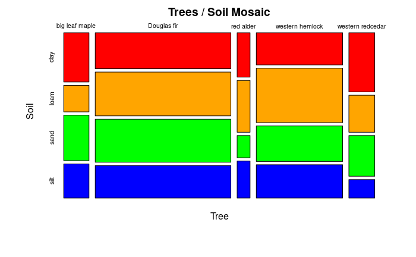

```r
mosaicplot(treesoiltab, title <- 'Trees / Soil Mosaic', col = c('red', 'orange', 'green', 'blue'))
```

**(2d) Based on the mosaic plot from (2c), do you think there is an association between tree species and soil type? Justify your answer. (6 points)**

Not really, nothing jumps out immediately. There are no clear indication that any tree does better in one soil than another, or any trade-off between trees and soils. More importantly, trees do not seem to have a favorite soil.

**(2e) Conduct a Chi-squared test of independence to test your hypotheses in (2a). Paste your code and output below. (6 points)**

```r
chisq.test(treesoiltab)
```

```
    Pearson's Chi-squared test

data:  treesoiltab
X-squared = 13.205, df = 12, p-value = 0.3543
```

**(2f) Based on your output from (2e), what is your statistical conclusion and interpretation at alpha = 0.05? (10 points)**